[figure not shown]

# Correlação Linear de Pearson no R (trabalhando com dados em painel)

Trabalharemos com correlação bivariada (entre duas variáveis), e utilizaremos três tipos de correlação linear: a correlação de *Pearson* (paramétrica, e deverá atender alguns pressupostos para ser usada), a correlação não-paramétrica de *Spearman* e a também não-paramétrica de *Kendall*.

# 1 O que vamos executar?

- Verificar os pressupostos para a correlação de *Pearson* (normalidade, homocedasticidade, relação linear e ausência de *outliers*);
- Fazer os testes de correlação de *Pearson*(paramétrico) e as correlações não-paramétricas de *Spearman* e *Kendall*;
- Pedir o gráfico de dispersão e a matriz de correlação entre as variáveis.

# 2 Situação problema

O `Banco de Dados 10.csv` contém informações de 103 alunos submetidos a uma prova. Verifique se há relação entre a ansiedade pré-prova e o desempenho dos alunos. Descreva os resultados de forma apropriada.

# 3 Efetuando a Análise

É necessário seguir alguns passos importantes.

## 3.1 Passo 1: Carregar os pacotes de dados.

```r
if(!require(dplyr)) install.packages("dplyr")
library(dplyr)
if(!require(car)) install.packages("corrplot")
library(corrplot)
if(!require(ggplot2)) install.packages("ggplot2")
library(ggplot2)
```

## 3.2 Passo 2: Carregar o banco de dados.

Detalhe importante: selecionar o diretório de trabalho via *Session/Set Working Directory/Choose Directory*.

```r
dados <- read.csv2('Banco de Dados 10.csv', encoding = 'latin1')
glimpse(dados)
```

```
## Rows: 103
## Columns: 5
## $ ID.Aluno      <int> 1, 2, 3, 4, 5, 6, 7, 8, 9, 10, 11, 12, 13, 14, 15, 16, 1~
## $ Tempo.Revisão <int> 4, 11, 27, 53, 4, 22, 16, 21, 25, 18, 18, 16, 13, 18, 98~
## $ Nota          <int> 40, 65, 80, 80, 40, 70, 20, 55, 50, 40, 45, 85, 70, 50, ~
## $ Ansiedade     <dbl> 86.30, 88.72, 70.18, 61.31, 89.52, 60.51, 81.46, 75.82, ~
## $ Gênero        <chr> "Masculino", "Feminino", "Masculino", "Masculino", "Masc~
```

```r
library(rmarkdown)
paged_table(dados)
```

| ID.Aluno | Tempo.Revisão | Nota | Ansiedade | Gênero |
| --- | --- | --- | --- | --- |
| 1 | 4 | 40 | 86.30 | Masculino |
| 2 | 11 | 65 | 88.72 | Feminino |
| 3 | 27 | 80 | 70.18 | Masculino |
| 4 | 53 | 80 | 61.31 | Masculino |
| 5 | 4 | 40 | 89.52 | Masculino |
| 6 | 22 | 70 | 60.51 | Feminino |
| 7 | 16 | 20 | 81.46 | Feminino |
| 8 | 21 | 55 | 75.82 | Feminino |
| 9 | 25 | 50 | 69.37 | Feminino |
| 10 | 18 | 40 | 82.27 | Feminino |

[output cut: 93 more lines]

## 3.3 Passo 3: Verificação dos pressupostos para a correlação de *Pearson*

Lembrando que a correlação de *Pearson* só vai fazer sentido dentro de um determinado contexto, ou seja, tendo atendido os pressupostos de normalidade, homogeneidade e verificação de *outliers*.

### 3.3.1 Verificação da normalidade - `shapiro.test`:

```r
shapiro.test(dados$Ansiedade)
```

```
##
##  Shapiro-Wilk normality test
##
## data:  dados$Ansiedade
## W = 0.82243, p-value = 8.653e-10
```

```r
shapiro.test(dados$Nota)
```

```
##
##  Shapiro-Wilk normality test
##
## data:  dados$Nota
## W = 0.95516, p-value = 0.001522
```

Pressupostos:

- H<sub>0</sub>: Distribuição dos dados = normal → p > 0,05
- H<sub>1</sub>: Distribuição dos dados ≠ normal → p ≤ 0,05

Verificamos assim que nem `Ansiedade` e nem `Nota` são variáveis que possuem distribuição normal, pois em ambos os casos, `p < 0.05`.

### 3.3.2 Verificação da presença de *outliers*:

Podemos usar o próprio gráfico de `boxplot`, ou a função `identify_outliers` do pacote `rstatix`, lembrando que ambos acabam chegando a conclusões diferentes porque, por mais que utilizem o mesmo critério (baseando o *outlier* como um valor fora do 1,5 da amplitude interquartil), a grande diferença é que o `boxplot` usa os quartis calculados excluindo a mediana, e a função `identify_outliers` inclui a mediana. Em conjuntos muito grande de dados, isso não faz diferença, mas em conjunto menor de dados (como o caso desse exercício), verificamos diferença.

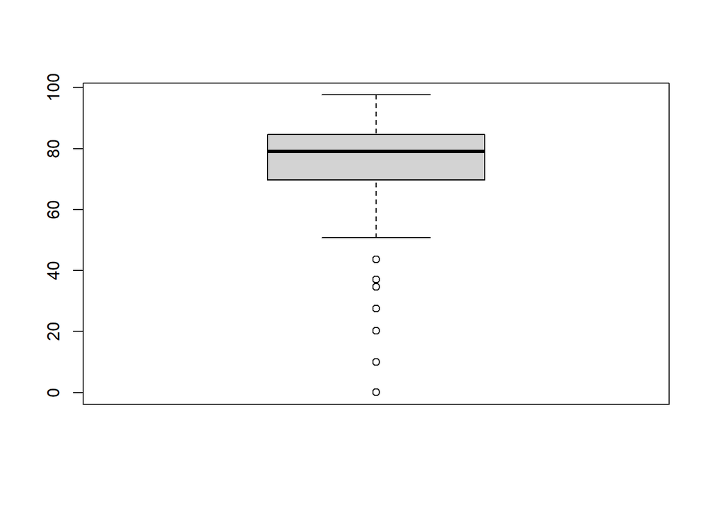

```r
boxplot(dados$Ansiedade)
```

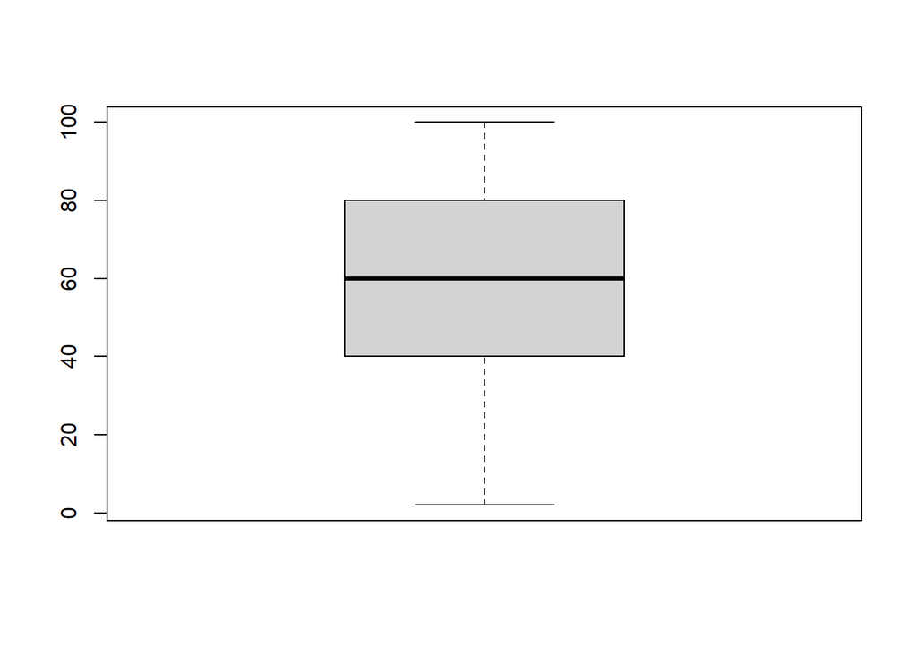

```r
boxplot(dados$Nota)
```

Pelo gráfico podemos ver que existem *outliers* para a variável `Ansiedade`, mas não para `Nota`. No entanto, outra coisa importante para ser verificado, antes de fazer a correlação de *Pearson*, é entender como a correlação entre as variáveis se comporta. Quando aplicamos a correlação de *Pearson*, ela verifica a correlação linear entre as variáveis. Olhando para o padrão de distribuição dos dados em um gráfico, é possível ver se, caso não exista uma correlação linear, pode ser que haja uma relação quadrática (se os dados estiverem formando os pontos em uma parábola, por exemplo).

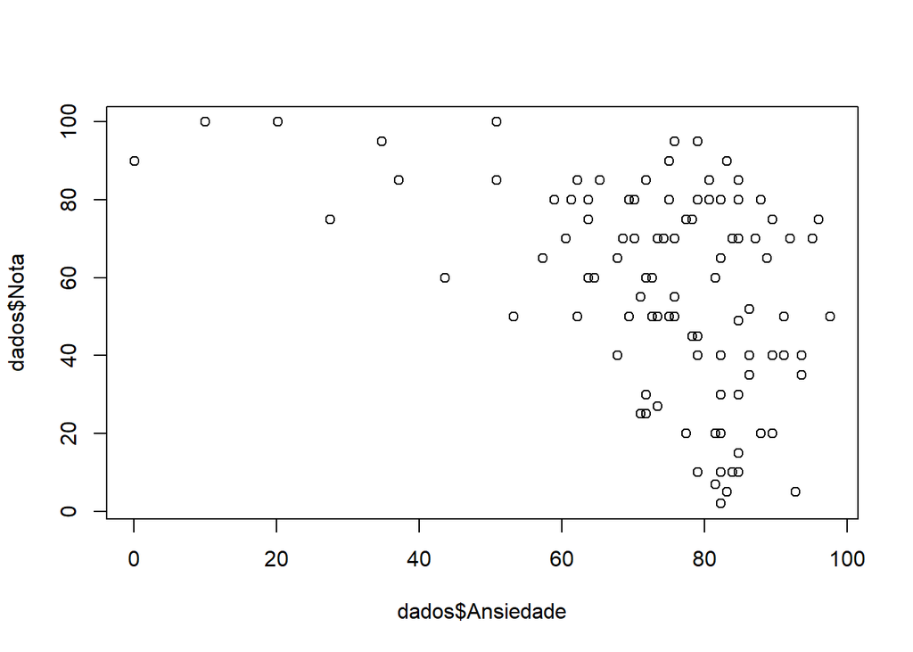

```r
plot(dados$Ansiedade, dados$Nota)
```

Nesse caso, vemos que a nuvem de pontos assume um comportamento ainda de difícil comparação com uma reta, ou mesmo com uma parábora.

## 3.4 Passo 4: Verificação dos pressupostos nos resíduos

Outro pressuposto muito importante é a homocedasticidade, e para testar precisamos construir primeiro um modelo de regressão linear porque conseguimos visualizar melhor a homocedasticidade quando olhamos para os resíduos, e não para os dados brutos.

### 3.4.1 Construção do modelo:

```r
mod_reg <- lm(Nota ~ Ansiedade, dados)
```

### 3.4.2 Análise gráfica:

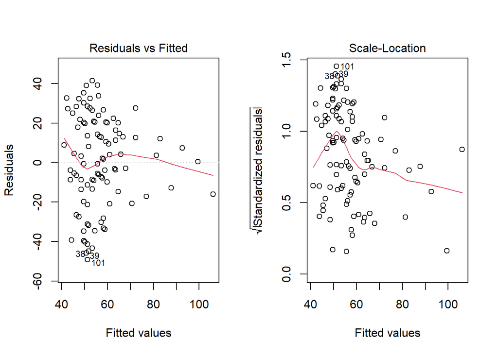

```r
par(mfrow=c(1,2))
plot(mod_reg, which=c(1,3))
```

```r
par(mfrow=c(1,1))
```

Inserimos, ao final do código `plot(mod_reg, which=c(1,3))` dois gráficos padronizados do R, no comando plot, sendo:

Gráfico 1: valores previstos x resíduos

Permite verificar se há homogeneidade de variâncias (homocedasticidade) - resíduos distribuídos de acordo com um padrão aproximadamente retangular. Também permite verificar se a relação entre as variáveis é linear, com a linha vermelha aproximadamente horizontal.

Gráfico 3: valores previstos x resíduos padronizados

Permite verificar se há outliers - valores de resíduos padronizados acima de 3 ou abaixo de -3.

Dessa forma, analisando os dois gráficos, podemos ver que não existe homocedasticidade porque os erros não estão padronizadamente distribuídos - verifica-se uma diminuição na diferença dos valores esperados e dos valores apresentados a medida que aumentamos o valor da amostra, ou seja, o modelo é **heterocedástico** (não existe homocedasticidade)

Dado o exposto, verificamos que o modelo não atende aos pressupostos da correlação de *Pearson*, que seria a normalidade dos dados, a verificação de *outliers* e a homocedasticidade do modelo, mas faremos a correlação mesmo assim a fim de estudarmos como o modelo se comporta.

## 3.5 Passo 5: Realização da correlação

### 3.5.1 Correlação *Linear de Pearson* (coeficiente = r):

A fim de entendermos a ideia por trás do teste, precisamos ver a hipótese nula e a hipótese alternativa, conforme a regra:

H<sub>0</sub>: Coeficiente = 0 → p > 0,05  
H<sub>1</sub>: Coeficiente ≠ 0 → p ≤ 0,05

Verificamos que o valor de `p < 0`, apesar de o valor apresentado de correlação ser fraco, estatisticamente é diferente de zero.

```r
cor.test(dados$Nota, dados$Ansiedade, method = "pearson")
```

```
##
##  Pearson's product-moment correlation
##
## data:  dados$Nota and dados$Ansiedade
## t = -4.9382, df = 101, p-value = 3.126e-06
## alternative hypothesis: true correlation is not equal to 0
## 95 percent confidence interval:
##  -0.5846328 -0.2705709
## sample estimates:
##        cor
## -0.4410037
```

### 3.5.2 Correlação de *Postos de Spearman* (coeficiente = r):

```r
cor.test(dados$Nota, dados$Ansiedade, method = "spearman")
```

```
##
##  Spearman's rank correlation rho
##
## data:  dados$Nota and dados$Ansiedade
## S = 255786, p-value = 2.245e-05
## alternative hypothesis: true rho is not equal to 0
## sample estimates:
##        rho
## -0.4046141
```

### 3.5.3 Correlação *Tau de Kendall* (coeficiente = tau):

```r
cor.test(dados$Nota, dados$Ansiedade, method = "kendall")
```

```
##
##  Kendall's rank correlation tau
##
## data:  dados$Nota and dados$Ansiedade
## z = -4.113, p-value = 3.906e-05
## alternative hypothesis: true tau is not equal to 0
## sample estimates:
##        tau
## -0.2847919
```

Verificamos então que a correlação para todos os casos é diferente de zero.

## 3.6 Passo 6: Gráfico de dispersão

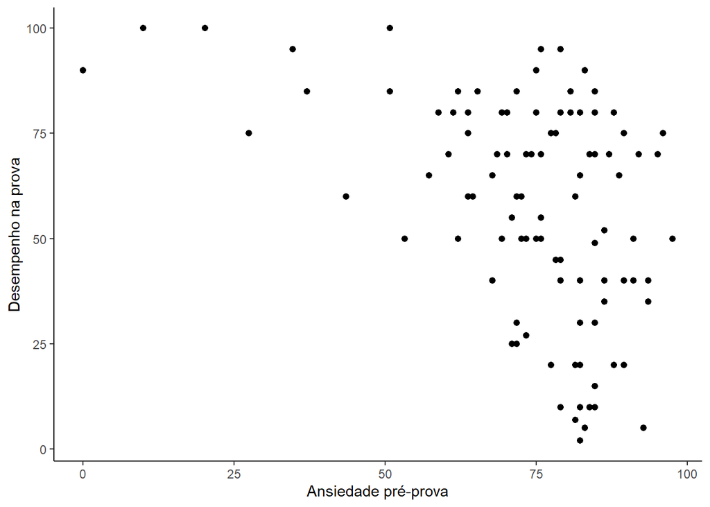

```r
ggplot(dados, aes(x = Ansiedade, y = Nota)) +
  labs(x = "Ansiedade pré-prova", y = "Desempenho na prova") +
  geom_point(size = 1.8) +
  theme_classic()
```

## 3.7 Passo 7 (opcional): Matrizes de correlação

### 3.7.1 Criando a matriz:

```r
matriz <- cor(dados[2:4], method = "pearson")
head.matrix(matriz)
```

```
##               Tempo.Revisão       Nota  Ansiedade
## Tempo.Revisão     1.0000000  0.3967207 -0.7092635
## Nota              0.3967207  1.0000000 -0.4410037
## Ansiedade        -0.7092635 -0.4410037  1.0000000
```

### 3.7.2 Arredondando para duas casas decimais:

```r
matriz <- round(cor(dados[2:4], method = "pearson"), 2)
head.matrix(matriz)
```

```
##               Tempo.Revisão  Nota Ansiedade
## Tempo.Revisão          1.00  0.40     -0.71
## Nota                   0.40  1.00     -0.44
## Ansiedade             -0.71 -0.44      1.00
```

### 3.7.3 Criando uma matriz visual (pacote `corrplot`)

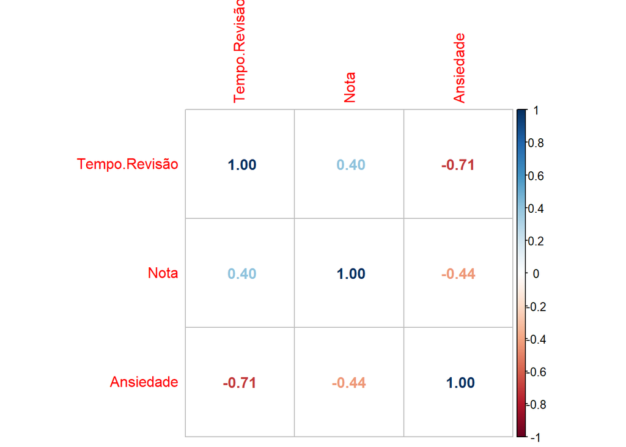

```r
corrplot(matriz, method = "number")
```

Opções de métodos: `method = circle, color, pie`  
Opções de tipos: `type = upper, lower`  
Ordenar: `order = hclust`

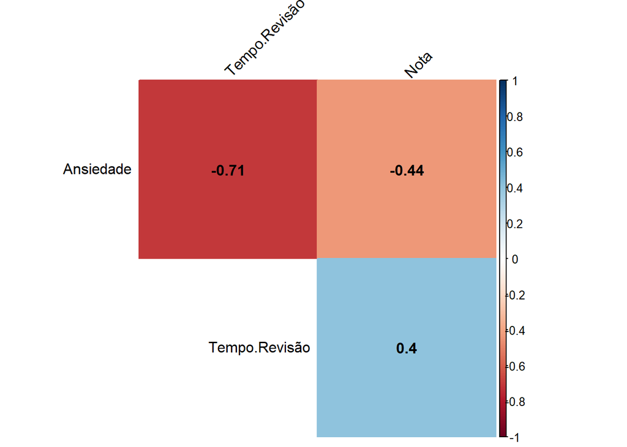

```r
corrplot(matriz, method = "color",
         type = "upper", order = "hclust",
         addCoef.col = "black", # adiciona o coeficiente à matriz
         tl.col = "black", tl.srt = 45, # cor e rotação do nome das variáveis
         diag = FALSE # não mostrar a diagonal principal
         )
```

# 4 Resultado

Verificamos, assim que a correlação de *Spearman* mostrou que há uma correlação negativa e fraca entre a ansidade pré-prova e a nota do aluno (rho = -0,40, p < 0,001).